Sphyrna lewini

BOLDGenotyper v1.0.0

# Sphyrna lewini

BOLDGenotyper Analysis Report

Generated: 2025-11-20 15:43:27

617

Total Samples

10

Genotypes

96.3%

Assignment Rate

## Analysis Summary

Total Samples

617

Samples analyzed

With Sequence Data

598

96.9% of total

Consensus Groups

10

Unique genotypes identified

Species Identified

1

Distinct species

Successfully Assigned

594

96.3% assignment rate

For assigned samples

Geographic coverage

## Pipeline Parameters

The following parameters were used for this analysis:

| Parameter | Value | Description |
| --- | --- | --- |
| **Clustering Threshold** | `0.015` (98.5% identity) | Maximum genetic distance for grouping sequences into consensus genotypes. Lower values create more groups with tighter genetic similarity. |
| **Similarity Threshold** | `0.5` (50% identity) | Minimum sequence identity required for assigning samples to genotypes. Samples below this threshold are marked as unassigned. |
| **Tie Margin** | `0.001` (0.1% difference) | Maximum identity difference between top matches to flag as ambiguous. Samples with (best - runner-up) < tie margin are flagged for manual review. |
| **Tie Threshold** | `0.95` (95% identity) | Minimum best-match identity required to consider tie detection. Prevents flagging low-quality matches as ties. |
| **Threads** | `4` | Number of parallel processing threads used. |
| **Phylogenetic Tree** | `True` | Whether phylogenetic tree was constructed. |

## Visualizations

📁 High-resolution images (PNG/PDF) and data files (JSON/CSV) available in output directories (see individual plots for locations)

### Identity Distribution

Distribution of sequence identity scores for assigned samples

📁 Files: `genotype_assignments/Sphyrna lewini_identity_distribution.png`, `Sphyrna lewini_identity_distribution.pdf`

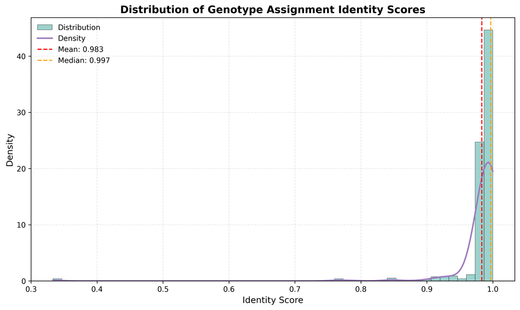

### Phylogenetic Tree

Phylogenetic tree showing relationships between consensus groups

📁 Files: `phylogenetic/Sphyrna lewini_tree.png`, `Sphyrna lewini_tree.pdf`

💡 Newick tree file available at `phylogenetic/Sphyrna lewini_tree_relabeled.nwk` for opening in tree editors such as [TreeViewer](https://treeviewer.org/) (Bianchini & Sánchez-Baracaldo, 2024) for re-rooting and customization

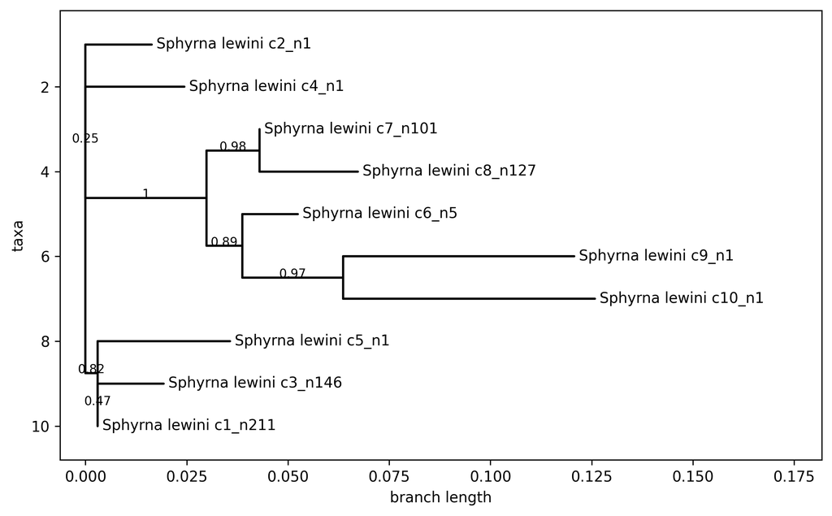

### Relative Abundance by Ocean Basin

Relative abundance of genotypes across ocean basins

📁 Files: `visualization/Sphyrna lewini_distribution_bar.png`, `Sphyrna lewini_distribution_bar.pdf`, `Sphyrna lewini_distribution_bar_data.json`

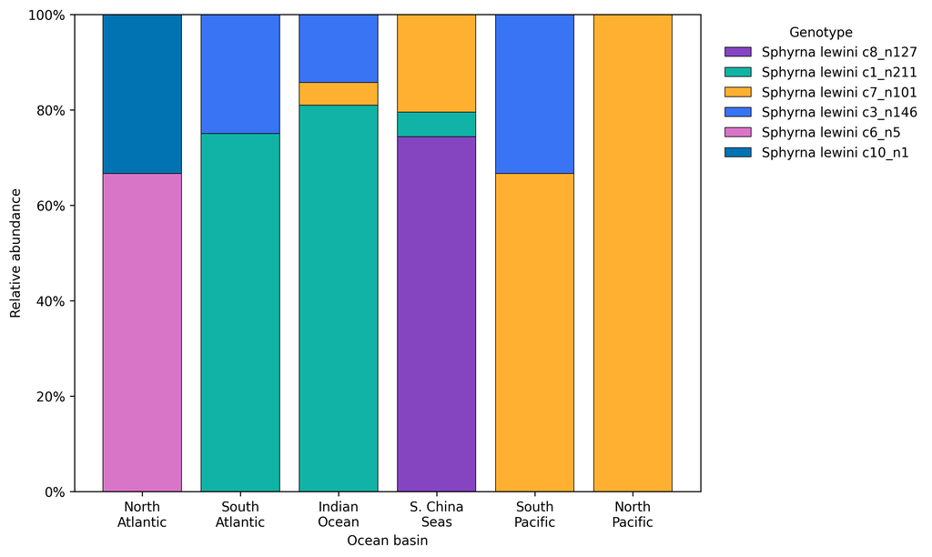

### Total Abundance by Ocean Basin

Total sample counts of genotypes across ocean basins

📁 Files: `visualization/Sphyrna lewini_totaldistribution_bar.png`, `Sphyrna lewini_totaldistribution_bar.pdf`, `Sphyrna lewini_totaldistribution_bar_data.json`

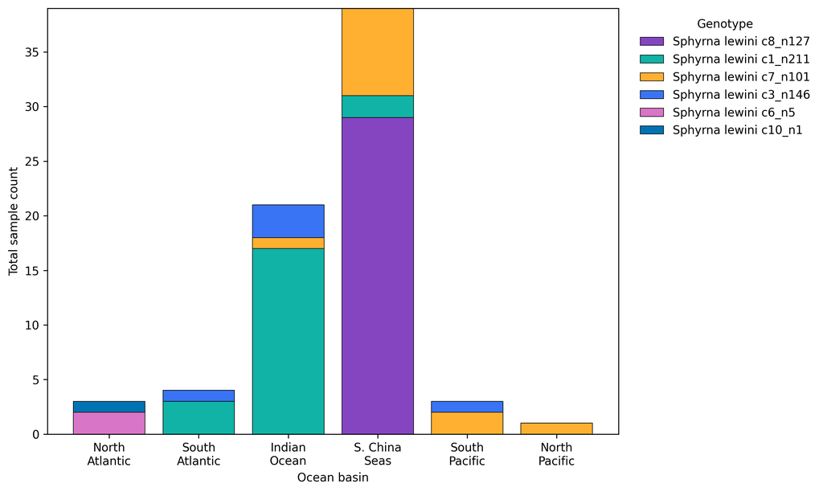

### Total Abundance by Ocean Basin (Faceted)

Total sample counts faceted by species or genotype

📁 Files: `visualization/Sphyrna lewini_distribution_bar_faceted.png`, `Sphyrna lewini_distribution_bar_faceted.pdf`, `Sphyrna lewini_distribution_bar_faceted_data.json`

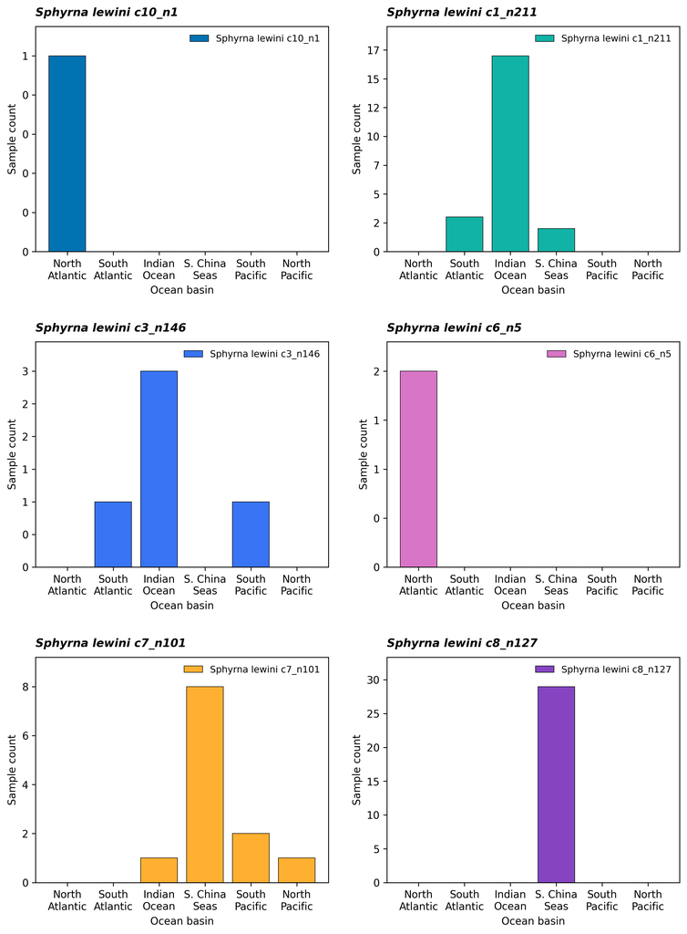

### Distribution Map

Geographic distribution of samples

📁 Files: `visualization/Sphyrna lewini_distribution_map.png`, `Sphyrna lewini_distribution_map.pdf`, `Sphyrna lewini_distribution_map_data.json`

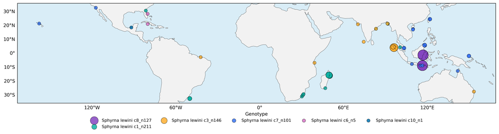

### Distribution Map (Faceted)

Geographic distribution faceted by species or genotype

📁 Files: `visualization/Sphyrna lewini_distribution_map_faceted.png`, `Sphyrna lewini_distribution_map_faceted.pdf`

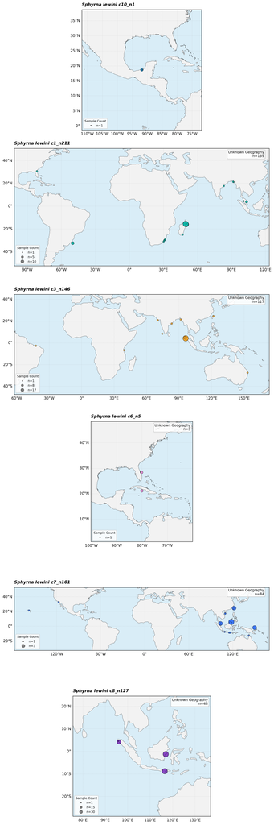

## Methods

Comprehensive analysis methodology and parameters suitable for reporting in peer-reviewed publications.

### 1. Analysis Overview

| **Pipeline Version** | BOLDGenotyper v1.0.0 |
| --- | --- |
| **Analysis Date** | 2025-11-20 |
| **Input File** | `data/Sphyrna_lewini_scallopedhammerhead.tsv` |

### 2. Sample Processing & Quality Control

| **Total samples loaded** | 685 |
| --- | --- |
| **Duplicate samples removed** | 10 |
| **Unique samples after deduplication** | 675 |
| **Coordinate quality filtering** | 617/675 (91.4%) retained |
| **Centroid coordinates excluded** | 58 |
| **Valid sequences for analysis** | 598 |
| **Missing/invalid sequences excluded** | 19 |
| **Sequences too short after trimming** | 3 |

### 3. Sequence Dereplication

| **Algorithm** | Hierarchical clustering (average linkage) |
| --- | --- |
| **Alignment** | MAFFT `--auto --thread 4` |
| **Trimming** | trimAl |
| **Minimum sequence length** | 400 bp |
| **Clustering threshold** | 0.015 (98.5% identity) |
| **Pairwise comparisons** | 176,715 |
| **Consensus genotypes identified** | 10 |

### 4. Genotype Assignment

[output not shown]

### 5. Phylogenetic Analysis

| **Alignment** | MAFFT `--auto --thread 4` |
| --- | --- |
| **Tree inference** | FastTree |
| **FastTree parameters** | `-nt -gtr -gamma` |
| **Substitution model** | GTR+Gamma |
| **Number of taxa** | 10 |

### 6. Geographic Analysis

| **Reference dataset** | GOaS v1 (Global Oceans and Seas) |
| --- | --- |
| **Samples with coordinates** | 171/617 (27.7%) |
| **Ocean basin assignments** | 71/171 (41.5%) |
| **Outside known basins** | 100 |
| **Unknown location** | 546 samples |

### 7. Software & Dependencies

| **BOLDGenotyper** | v1.0.0 |
| --- | --- |
| **MAFFT** | Multiple sequence alignment (Katoh & Standley, 2013) |
| **trimAl** | Alignment trimming (Capella-Gutiérrez et al., 2009) |
| **FastTree** | Phylogenetic inference (Price et al., 2010) |
| **edlib** | Edit distance calculation (Šošić & Šikić, 2017) |
| **GOaS** | Global Oceans and Seas dataset (Flanders Marine Institute, 2021) |

### 9. References

Bianchini, G., & Sánchez-Baracaldo, P. (2024). TreeViewer: Flexible, modular software to visualise and manipulate phylogenetic trees. *Ecology and Evolution*, 14, e10873. https://doi.org/10.1002/ece3.10873

Capella-Gutiérrez, S., Silla-Martínez, J. M., & Gabaldón, T. (2009). trimAl: a tool for automated alignment trimming in large-scale phylogenetic analyses. *Bioinformatics*, 25(15), 1972-1973.

Flanders Marine Institute (2021). Global Oceans and Seas, version 1. Available online at https://www.marineregions.org/

Katoh, K., & Standley, D. M. (2013). MAFFT multiple sequence alignment software version 7: improvements in performance and usability. *Molecular Biology and Evolution*, 30(4), 772-780.

Price, M. N., Dehal, P. S., & Arkin, A. P. (2010). FastTree 2 – Approximately maximum-likelihood trees for large alignments. *PLoS ONE*, 5(3), e9490.

Ratnasingham, S., & Hebert, P. D. (2007). BOLD: The Barcode of Life Data System. *Molecular Ecology Notes*, 7(3), 355-364.

Šošić, M., & Šikić, M. (2017). Edlib: a C/C++ library for fast, exact sequence alignment using edit distance. *Bioinformatics*, 33(9), 1394-1395.

## Genotype Assignment Results

### Assignment Status Breakdown

| Status | Count | Percentage |
| --- | --- | --- |
| Successfully Assigned | 594 | 96.3% |
| Low Confidence | 0 | 0.0% |
| Tied Assignment | 1 | 0.2% |
| Below Threshold | 3 | 0.5% |
| No Sequence Data | 19 | 3.1% |

### Identity Score Statistics (Assigned Samples)

[output not shown]

## Taxonomy

### Consensus Group Taxonomy

| consensus_group | assigned_sp | assignment_level | assignment_notes | majority_fraction |
| --- | --- | --- | --- | --- |
| consensus_c10_n1 | Sphyrna lewini | species | majority 1.00 | 1.0 |
| consensus_c1_n211 | Sphyrna lewini | species | majority 1.00 | 1.0 |
| consensus_c2_n1 | Sphyrna lewini | species | majority 1.00 | 1.0 |
| consensus_c3_n146 | Sphyrna lewini | species | majority 1.00 | 1.0 |
| consensus_c4_n1 | Sphyrna lewini | species | majority 1.00 | 1.0 |
| consensus_c5_n1 | Sphyrna lewini | species | majority 1.00 | 1.0 |
| consensus_c6_n5 | Sphyrna lewini | species | majority 1.00 | 1.0 |
| consensus_c7_n101 | Sphyrna lewini | species | majority 1.00 | 1.0 |
| consensus_c8_n127 | Sphyrna lewini | species | majority 1.00 | 1.0 |
| consensus_c9_n1 | Sphyrna lewini | species | majority 1.00 | 1.0 |

### Species Composition by Consensus Group

| consensus_group | reported_species | n | frac | n_in_group |
| --- | --- | --- | --- | --- |
| consensus_c10_n1 | Sphyrna lewini | 1 | 1.0 | 1.0 |
| consensus_c1_n211 | Sphyrna lewini | 211 | 1.0 | 211.0 |
| consensus_c2_n1 | Sphyrna lewini | 1 | 1.0 | 1.0 |
| consensus_c3_n146 | Sphyrna lewini | 146 | 1.0 | 146.0 |
| consensus_c4_n1 | Sphyrna lewini | 1 | 1.0 | 1.0 |
| consensus_c5_n1 | Sphyrna lewini | 1 | 1.0 | 1.0 |
| consensus_c6_n5 | Sphyrna lewini | 5 | 1.0 | 5.0 |
| consensus_c7_n101 | Sphyrna lewini | 101 | 1.0 | 101.0 |
| consensus_c8_n127 | Sphyrna lewini | 127 | 1.0 | 127.0 |
| consensus_c9_n1 | Sphyrna lewini | 1 | 1.0 | 1.0 |
| NaN | Sphyrna lewini | 22 | NaN | NaN |

## Geographic Distribution

**Geographic Analysis Summary:** 71 of 617 samples (11.5%) have defined geographic locations. 546 samples (88.5%) with unknown or missing geography were excluded from geographic analyses.

### Sample Distribution by Ocean Basin

| Ocean Basin | Sample Count | Percentage |
| --- | --- | --- |
| South China and Easter Archipelagic Seas | 39 | 54.9 |
| Indian Ocean | 21 | 29.6 |
| South Atlantic Ocean | 4 | 5.6 |
| North Atlantic Ocean | 3 | 4.2 |
| South Pacific Ocean | 3 | 4.2 |
| North Pacific Ocean | 1 | 1.4 |

### Genotypes per Ocean Basin

| ocean_basin | consensus_group | Indian Ocean | North Atlantic Ocean | North Pacific Ocean | South Atlantic Ocean | South China and Easter Archipelagic Seas | South Pacific Ocean |
| --- | --- | --- | --- | --- | --- | --- | --- |
|  | consensus_c10_n1 | 0 | 1 | 0 | 0 | 0 | 0 |
|  | consensus_c1_n211 | 17 | 0 | 0 | 3 | 2 | 0 |
|  | consensus_c3_n146 | 3 | 0 | 0 | 1 | 0 | 1 |
|  | consensus_c6_n5 | 0 | 2 | 0 | 0 | 0 | 0 |
|  | consensus_c7_n101 | 1 | 0 | 1 | 0 | 8 | 2 |
|  | consensus_c8_n127 | 0 | 0 | 0 | 0 | 29 | 0 |

**Missing Geography:** 446 samples (72.3%) do not have valid coordinate data.

**BOLDGenotyper** - Automated genotyping pipeline for BOLD barcode data  
[GitHub Repository](https://github.com/SymbioSeas/BOLDGenotyper) | Created by Steph Smith

Report generated on 2025-11-20 15:43:27  
For questions or issues, please visit the GitHub repository.